# MEDL_HW10_Soln

# Problem 2: LSTM with TensorFlow

- In this problem, you will make a LSTM model to predict the half of an MNIST image using the other half.
- You will split an MNIST image into 28 pieces.
- MNIST is 28 x 28 image. The model predicts a piece of 1 x 28 image.
- First, 14 x 28 image will be feeded into a model as time series, then the model predict the last 14 x 28 image, recursively.

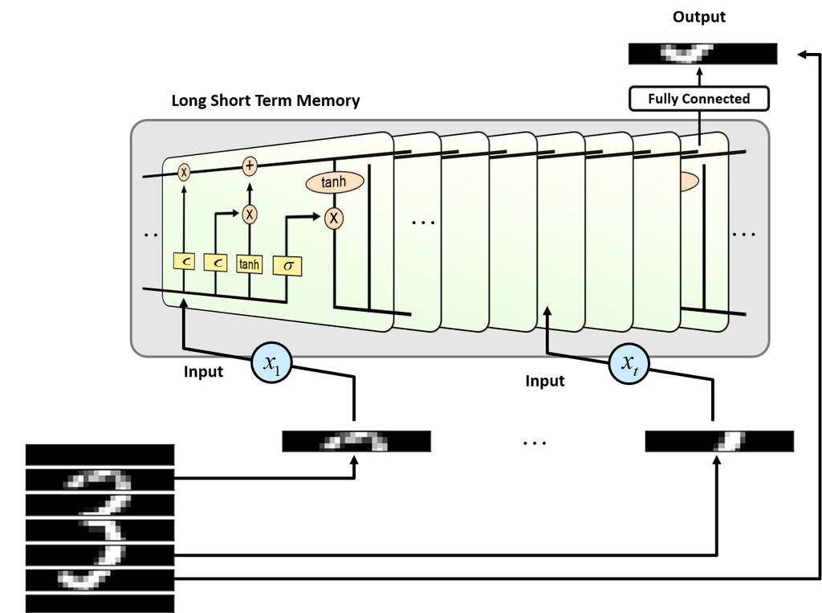

(0) Import libraries

```python
import tensorflow as tf
import numpy as np
import matplotlib.pyplot as plt
```

(1) Load MNIST Data

- Download MNIST data from the tensorflow tutorial example

```python
from tensorflow.examples.tutorials.mnist import input_data
mnist = input_data.read_data_sets("MNIST_data/", one_hot=True)
```

```
Extracting MNIST_data/train-images-idx3-ubyte.gz
Extracting MNIST_data/train-labels-idx1-ubyte.gz
Extracting MNIST_data/t10k-images-idx3-ubyte.gz
Extracting MNIST_data/t10k-labels-idx1-ubyte.gz
```

(2) Randomly plot a data with its label

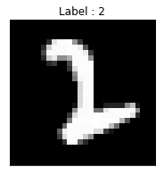

```python
train_x, train_y = mnist.train.next_batch(10)
img = train_x[9,:].reshape(28, 28)

plt.figure(figsize=(5, 3))
plt.imshow(img,'gray')
plt.title("Label : {}".format(np.argmax(train_y[9])))
plt.xticks([])
plt.yticks([])
plt.show()
```

(3) Define RNN Structure

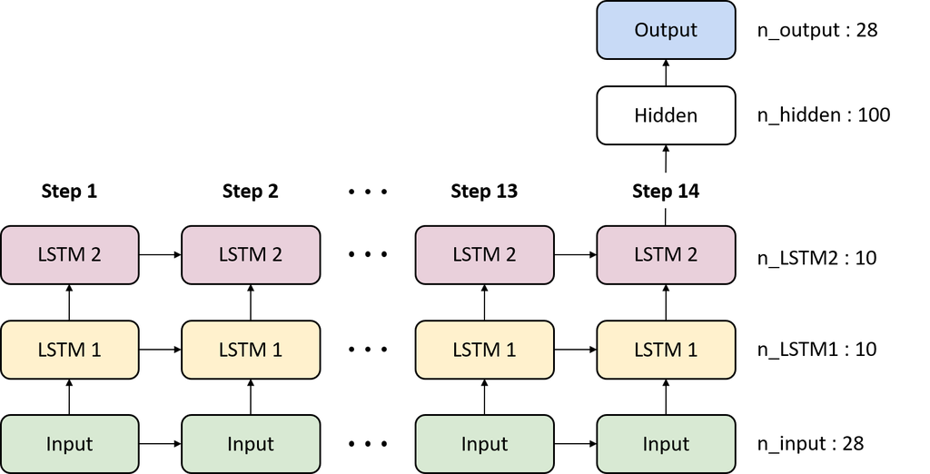

```python
n_step = 14
n_input = 28

## LSTM shape
n_lstm1 = 10
n_lstm2 = 10

## Fully connected
n_hidden = 100
n_output = 28
```

(4) Define Weights and Biases

**LSTM Cell**

- Do not need to define weights and biases of LSTM cells

**Fully connected**

- Define parameters based on the predefined layer size
- Initialize with a normal distribution with $\mu = 0$ and $\sigma = 0.01$

```python
weights = {
    'hidden' : tf.Variable(tf.random_normal([n_lstm2, n_hidden], stddev=0.01)),
    'output' : tf.Variable(tf.random_normal([n_hidden, n_output], stddev=0.01))
}

biases = {
    'hidden' : tf.Variable(tf.random_normal([n_hidden], stddev=0.01)),
    'output' : tf.Variable(tf.random_normal([n_output], stddev=0.01))
}

x = tf.placeholder(tf.float32, [None, n_step, n_input])
y = tf.placeholder(tf.float32, [None, n_output])
```

(5) Build a Model

**Build the RNN Network**

- First, define the LSTM cells  
  `lstm = tf.contrib.rnn.BasicLSTMCell(n_lstm)`
- Second, compute hidden state (h) and lstm cell (c) with the predefined lstm cell and input  
  `h, c = tf.nn.dynamic_rnn(lstm, input_tensor, dtype=tf.float32)`

```python
def build_model(x, weights, biases):
    with tf.variable_scope('rnn'):
        # Build RNN network
        with tf.variable_scope('lstm1'):
            lstm1 = tf.contrib.rnn.BasicLSTMCell(n_lstm1)
            h1, c1 = tf.nn.dynamic_rnn(lstm1, x, dtype=tf.float32)
        with tf.variable_scope('lstm2'):
            lstm2 = tf.contrib.rnn.BasicLSTMCell(n_lstm2)
            h2, c2 = tf.nn.dynamic_rnn(lstm2, h1, dtype=tf.float32)

        # Build classifier
        hidden = tf.add(tf.matmul(h2[:,-1,:], weights['hidden']), biases['hidden'])
        hidden = tf.nn.relu(hidden)
        output = tf.add(tf.matmul(hidden, weights['output']), biases['output'])
        return output
```

(6) Define Cost, Initializer and Optimizer Loss

- Regression: Squared loss

$$ \frac{1}{N} \sum_{i=1}^{N} (\hat{y}^{(i)} - y^{(i)})^2$$

Initializer

- Initialize all the empty variables

Optimizer

- AdamOptimizer: the most popular optimizer

```python
LR = 0.0005

pred = build_model(x, weights, biases)
loss = tf.square(tf.subtract(y, pred))
loss = tf.reduce_mean(loss)

optm = tf.train.AdamOptimizer(LR).minimize(loss)

init = tf.global_variables_initializer()
```

(7) Define optimization configuration and then optimize

Highly recommand to use GPU or Colab.

```python
n_iter = 5000
n_prt = 100
```

```python
sess = tf.Session()
sess.run(init)

for i in range(n_iter+1):
    train_x, train_y = mnist.train.next_batch(50)
    train_x = train_x.reshape(-1, 28, 28)

    for j in range(n_step):
        sess.run(optm, feed_dict={x: train_x[:,j:j+n_step,:],  y: train_x[:,j+n_step]})
    if i % n_prt == 0:
        c = sess.run(loss, feed_dict={x: train_x[:,13:13+n_step,:],  y: train_x[:,13+n_step]})
        print ("Iter : {:4d}, Cost : {:.6f}".format(i, c))
```

```
Iter :    0, Cost : 0.000586
Iter :  100, Cost : 0.002815
Iter :  200, Cost : 0.002513
Iter :  300, Cost : 0.000506
Iter :  400, Cost : 0.001673
Iter :  500, Cost : 0.004014
Iter :  600, Cost : 0.001104
Iter :  700, Cost : 0.005710
Iter :  800, Cost : 0.001293
Iter :  900, Cost : 0.002701
Iter : 1000, Cost : 0.002157
Iter : 1100, Cost : 0.001358
Iter : 1200, Cost : 0.002636
Iter : 1300, Cost : 0.003864
Iter : 1400, Cost : 0.002782
Iter : 1500, Cost : 0.002859
Iter : 1600, Cost : 0.001920
Iter : 1700, Cost : 0.000812
Iter : 1800, Cost : 0.000783
Iter : 1900, Cost : 0.002742
Iter : 2000, Cost : 0.001434
Iter : 2100, Cost : 0.002981
Iter : 2200, Cost : 0.002727
Iter : 2300, Cost : 0.002188
Iter : 2400, Cost : 0.003785
Iter : 2500, Cost : 0.000973
Iter : 2600, Cost : 0.001997
Iter : 2700, Cost : 0.001199
Iter : 2800, Cost : 0.001164
Iter : 2900, Cost : 0.001392
Iter : 3000, Cost : 0.000286
Iter : 3100, Cost : 0.004101
Iter : 3200, Cost : 0.000352
Iter : 3300, Cost : 0.002220
Iter : 3400, Cost : 0.001170
Iter : 3500, Cost : 0.000600
Iter : 3600, Cost : 0.000757
Iter : 3700, Cost : 0.001677
Iter : 3800, Cost : 0.000388
Iter : 3900, Cost : 0.003937
Iter : 4000, Cost : 0.000250
Iter : 4100, Cost : 0.003955
Iter : 4200, Cost : 0.001565
Iter : 4300, Cost : 0.001821
Iter : 4400, Cost : 0.000682
Iter : 4500, Cost : 0.000571
Iter : 4600, Cost : 0.001102
Iter : 4700, Cost : 0.000935
Iter : 4800, Cost : 0.000877
Iter : 4900, Cost : 0.002451
Iter : 5000, Cost : 0.002426
```

(8) Test or Evaluate

- Predict the MNIST image
- MNIST is 28 x 28 image. The model predicts a piece of 1 x 28 image.
- First, 14 x 28 image will be feeded into a model, then the model predict the last 14 x 28 image, recursively.

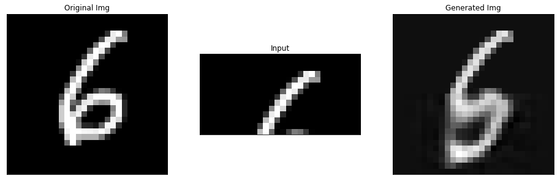

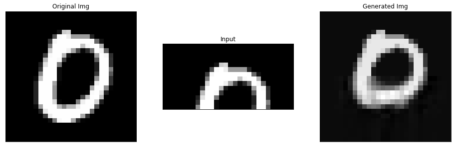

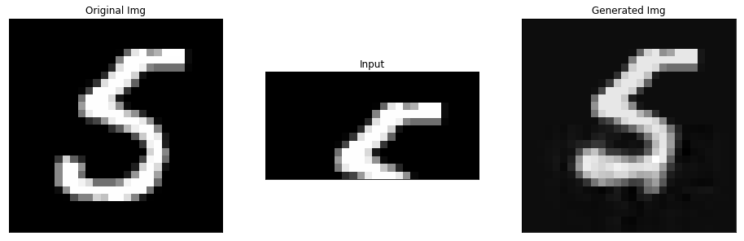

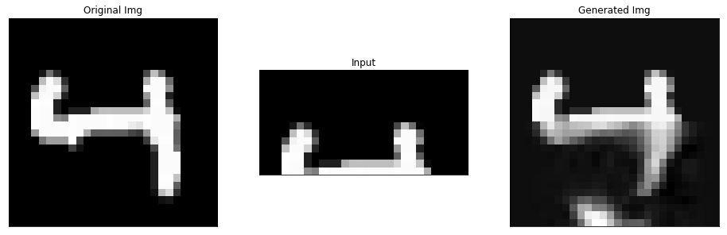

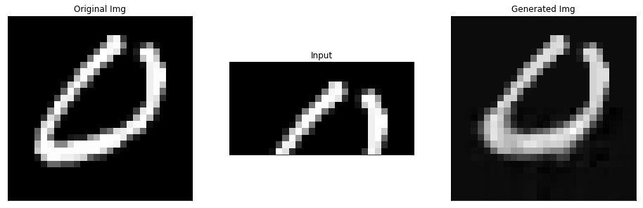

```python
test_x, test_y = mnist.test.next_batch(5)
test_x = test_x.reshape(-1, 28, 28)

for idx in range(5):
    gen_img = []

    sample = test_x[idx, 0:14, :]
    input_img = sample.copy()

    feeding_img = test_x[idx, 0:0+n_step, :]

    for i in range(n_step):
        test_pred = sess.run(pred, feed_dict={x: feeding_img.reshape(1, 14, 28)})
        feeding_img = np.delete(feeding_img, 0, 0)
        feeding_img = np.vstack([feeding_img, test_pred])
        gen_img.append(test_pred)

    for i in range(n_step):
        sample = np.vstack([sample, gen_img[i]])

    plt.figure(figsize=(16, 5))
    plt.subplot(1,3,1)
    plt.imshow(test_x[idx], 'gray')
    plt.title('Original Img')
    plt.xticks([])
    plt.yticks([])

    plt.subplot(1,3,2)
    plt.imshow(input_img, 'gray')
    plt.title('Input')
    plt.xticks([])
    plt.yticks([])

    plt.subplot(1,3,3)
    plt.imshow(sample, 'gray')
    plt.title('Generated Img')
    plt.xticks([])
    plt.yticks([])
    plt.show()
```